# Lecture 14 Causal Diagrams

Nick Huntington-Klein

February 25, 2019

## Recap

- Last time we talked about causality
- The idea that if we could reach in and manipulate `X`, and as a result `Y` changes too, then `X` *causes* `Y`
- We also talked about how we can identify causality in data
- Part of that will necessarily require us to have a model

## Models

- We *have to have a model* to get at causality
- A model is our way of *understanding the world*. It’s our idea of what we think the data-generating process is
- Models can be informal or formal - “The sun rises every day because the earth spins” vs. super-complex astronomical models of the galaxy with thousands of equations
- All models are wrong. Even quantum mechanics. But as long as models are right enough to be useful, we’re good to go!

## Models

- Once we *do* have a model, though, that model will tell us *exactly* how we can find a causal effect
- (if it’s possible; it’s not always possible)
- Sort of like how, last time, we knew how `X` was assigned, and using that information we were able to get a good estimate of the true treatment

## Example

- Let’s work through a familiar example from before, where we know the data generating process

```r
# Is your company in tech? Let's say 30% of firms are
df <- tibble(tech = sample(c(0,1),500,replace=T,prob=c(.7,.3))) %>%
  #Tech firms on average spend $3mil more defending IP lawsuits
  mutate(IP.spend = 3*tech+runif(500,min=0,max=4)) %>%
  #Tech firms also have higher profits. But IP lawsuits lower profits
  mutate(log.profit = 2*tech - .3*IP.spend + rnorm(500,mean=2))
# Now let's check for how profit and IP.spend are correlated!
cor(df$log.profit,df$IP.spend)
```

```
## [1] 0.1609575
```

- Uh-oh! Truth is negative relationship, but data says positive!!

## Example

- Now we can ask: *what do we know* about this situation?
- How do we suspect the data was generated? (ignoring for a moment that we know already)
  - We know that being a tech company leads you to have to spend more money on IP lawsuits
  - We know that being a tech company leads you to have higher profits
  - We know that IP lawsuits lower your profits

## Example

- From this, we realize that part of what we get when we calculate `cor(df$log.profit,df$IP.spend)` is the influence of being a tech company
- Meaning that if we remove that influence, what’s left over should be the actual, negative, effect of IP lawsuits
- Now, we can get to this intuitively, but it would be much more useful if we had a more formal model that could tell us what to do in *lots* of situations

## Causal Diagrams

- Enter the causal diagram!
- A causal diagram (aka a Directed Acyclic Graph) is a way of writing down your *model* that lets you figure out what you need to do to find your causal effect of interest
- All you need to do to make a causal diagram is write down all the important features of the data generating process, and also write down what you think causes what!

## Example

- We know that being a tech company leads you to have to spend more money on IP lawsuits
- We know that being a tech company leads you to have higher profits
- We know that IP lawsuits lower your profits

## Example

- We know that being a tech company leads you to have to spend more money on IP lawsuits
- We know that being a tech company leads you to have higher profits
- We know that IP lawsuits lower your profits

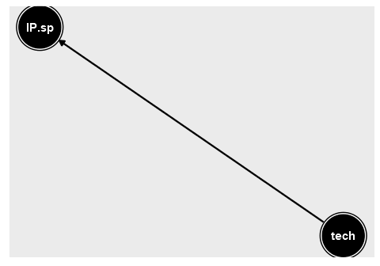

## Example

- We know that being a tech company leads you to have to spend more money on IP lawsuits
- We know that being a tech company leads you to have higher profits
- We know that IP lawsuits lower your profits

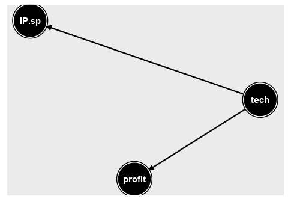

## Example

- We know that being a tech company leads you to have to spend more money on IP lawsuits
- We know that being a tech company leads you to have higher profits
- We know that IP lawsuits lower your profits

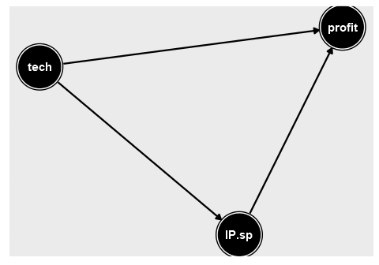

## Viola

- We have *encoded* everything we know about this particular little world in our diagram
- (well, not everything, the diagram doesn’t say whether we think these effects are positive or negative)
- Not only can we see our assumptions, but we can see how they fit together
- For example, if we were looking for the impact of *tech* on profit, we’d know that it happens directly, AND happens because tech affects `IP.spend`, which then affects profit.

## Identification

- And if we want to isolate the effect of `IP.spend` on `profit`, we can figure that out too
- We call this process - isolating just the causal effect we’re interested in - “identification”
- We’re *identifying* just one of those arrows, the one `IP.spend -> profit`, and seeing what the effect is on that arrow!

## Identification

- Based on this graph, we can see that part of the correlation between `IP.Spend` and `profit` can be *explained by* how `tech` links the two.

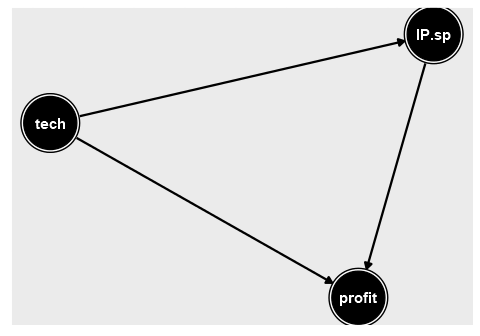

## Identification

- Since we can *explain* part of the correlation with `tech`, but we want to *identify* the part of the correlation that ISN’T explained by `tech` (the causal part), we will want to just use what isn’t explained by tech!
  - Use `tech` to explain `profit`, and take the residual
  - Use `tech` to explain `IP.spend`, and take the residual
  - The relationship between the first residual and the second residual is *causal*!

## Controlling

- This process is called “adjusting” or “controlling”. We are “controlling for tech” and taking out the part of the relationship that is explained by it
- In doing so, we’re looking at the relationship between `IP.spend` and `profit` *just comparing firms that have the same level of `tech`*.
- This is our “apples to apples” comparison that gives us an experiment-like result

## Controlling

```r
df <- df %>% group_by(tech) %>%
  mutate(log.profit.resid = log.profit - mean(log.profit),
         IP.spend.resid = IP.spend - mean(IP.spend)) %>% ungroup()
cor(df$log.profit.resid,df$IP.spend.resid)
```

```
## [1] -0.3018621
```

- Negative! Hooray

## Controlling

- Imagine we’re looking at that relationship *within color*

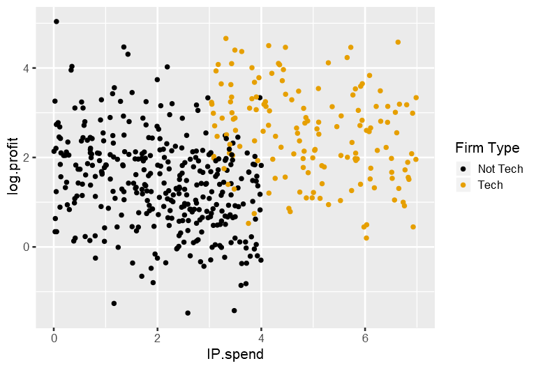

## LITERALLY

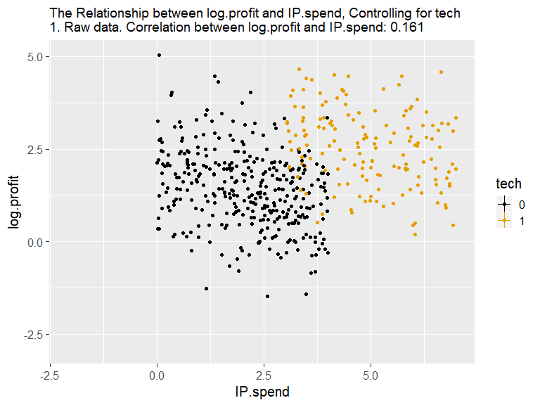

## Recap

- By controlling for `tech` (“holding it constant”) we got rid of the part of the `IP.spend`/`profit` relationship that was explained by `tech`, and so managed to *identify* the `IP.spend -> profit` arrow, the causal effect we’re interested in!
- We correctly found that it was negative
- Remember, we made it truly negative when we created the data, all those slides ago

## Causal Diagrams

- And it was the diagram that told us to control for `tech`
- It’s going to turn out that diagrams can tell us how to identify things in much more complex circumstances - we’ll get to that soon
- But you might have noticed that it was pretty obvious what to do just by looking at the graph

## Causal Diagrams

- Can’t we just look at the data to see what we need to control for?
- After all, that would free us from having to make all those assumptions and figure out our model
- No!!!
- Why? Because for a given set of data that we see, there are *many* different data generating processes that could have made it
- Each requiring different kinds of adjustments in order to get it right

## Causal Diagrams

- We observe that `profit` (y), `IP.spend` (x), and `tech` (z) are all related… which is it?

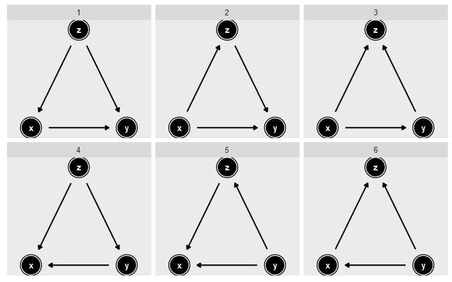

## Causal Diagrams

- With only the data to work with we have *literally no way of knowing* which of those is true
- Maybe `IP.spend` causes companies to be `tech` companies (in 2, 3, 6)
- We know that’s silly because we have an idea of what the model is
- But that’s what lets us know it’s wrong - the model. With just the data we have no clue.

## Causal Diagrams

- Next time we’ll set about actually making one of these diagrams
- And soon we’ll be looking for what the diagrams tell us about how to identify an effect!

## Practice

- Load in `data(swiss)` and use `help` to look at it
- Get the correlation between Fertility and Education
- Think about what direction the arrows might go on a diagram with Fertility, Education, and Agriculture
- Get the corrlelation between Fertility and Education *controlling for Agriculture* (use `cut` with `breaks=3`)

## Practice Answers

```r
data(swiss)
help(swiss)
cor(swiss$Fertility,swiss$Education)

swiss <- swiss %>%
  group_by(cut(Agriculture,breaks=3)) %>%
  mutate(Fert.resid = Fertility - mean(Fertility),
         Ed.resid = Education - mean(Education))

cor(swiss$Fert.resid,swiss$Ed.resid)
```

```
## [1] -0.6637889
```

```
## [1] -0.5560316
```